# Expansión de la CASEN sobre el CENSO (Región 16)

De ingresos sobre una categoría de respuesta

VE-CC-AJ

DataIntelligence

Jueves 16-06-2021

Abstract

Expandiremos los ingresos promedios comunales obtenidos de la CASEN sobre la categoría de respuesta: “tejas o tejuelas de arcilla, metálicas, de cemento, de madera, asfálticas o plásticas” del campo P03B del CENSO de viviendas, que fue la categoría de respuesta que más alto correlaciona con los ingresos expandidos (obtenidos de la multiplicación del ingreso promedio y los habitantes), ambos a nivel comunal.

Haremos el análisis sobre la región 16.

Ensayaremos diferentes modelos dentro del análisis de regresión cuya variable independiente será: “frecuencia de población que posee la variable Censal respecto a la zona” y la dependiente: “ingreso expandido por zona”

Lo anterior para elegir el que posea el mayor coeficiente de determinación y así contruir una tabla de valores predichos.

## 1 Variable CENSO

Necesitamos calcular las frecuencias a nivel censal de las respuestas correspondientes a la categoría: “tejas o tejuelas de arcilla, metálicas, de cemento, de madera, asfálticas o plásticas” del campo **P03B** del Censo de viviendas. Recordemos que ésta fué la más alta correlación en relación a los ingresos expandidos [(ver punto 1.2 aquí)](https://rpubs.com/dataintelligence/corr_004_viviendas).

### 1.1 Lectura y filtrado de la tabla censal de viviendas

```r
tabla_con_clave <- readRDS("censo_viviendas_con_clave_17.rds")
r3_100 <- tabla_con_clave[c(1:100),]
kbl(r3_100) %>%
  kable_styling(bootstrap_options = c("striped", "hover")) %>%
  kable_paper() %>%
  scroll_box(width = "100%", height = "300px")
```

| REGION | PROVINCIA | COMUNA | DC | AREA | ZC_LOC | ID_ZONA_LOC | NVIV | P01 | P02 | P03A | P03B | P03C | P04 | P05 | CANT_HOG | CANT_PER | REGION_15R | PROVINCIA_15R | COMUNA_15R | clave |
| --- | --- | --- | --- | --- | --- | --- | --- | --- | --- | --- | --- | --- | --- | --- | --- | --- | --- | --- | --- | --- |
| 15 | 152 | 15202 | 1 | 2 | 6 | 13225 | 1 | 3 | 1 | 5 | 3 | 5 | 1 | 4 | 1 | 1 | 15 | 152 | 15202 | 15202012006 |
| 15 | 152 | 15202 | 1 | 2 | 6 | 13225 | 2 | 1 | 3 | 98 | 98 | 98 | 98 | 98 | 0 | 0 | 15 | 152 | 15202 | 15202012006 |
| 15 | 152 | 15202 | 1 | 2 | 6 | 13225 | 3 | 1 | 1 | 5 | 3 | 5 | 2 | 3 | 1 | 4 | 15 | 152 | 15202 | 15202012006 |
| 15 | 152 | 15202 | 1 | 2 | 6 | 13225 | 4 | 1 | 4 | 98 | 98 | 98 | 98 | 98 | 0 | 0 | 15 | 152 | 15202 | 15202012006 |
| 15 | 152 | 15202 | 1 | 2 | 6 | 13225 | 5 | 3 | 4 | 98 | 98 | 98 | 98 | 98 | 0 | 0 | 15 | 152 | 15202 | 15202012006 |
| 15 | 152 | 15202 | 1 | 2 | 6 | 13225 | 6 | 3 | 4 | 98 | 98 | 98 | 98 | 98 | 0 | 0 | 15 | 152 | 15202 | 15202012006 |
| 15 | 152 | 15202 | 1 | 2 | 6 | 13225 | 7 | 3 | 4 | 98 | 98 | 98 | 98 | 98 | 0 | 0 | 15 | 152 | 15202 | 15202012006 |
| 15 | 152 | 15202 | 1 | 2 | 6 | 13225 | 8 | 3 | 3 | 98 | 98 | 98 | 98 | 98 | 0 | 0 | 15 | 152 | 15202 | 15202012006 |
| 15 | 152 | 15202 | 1 | 2 | 6 | 13225 | 9 | 3 | 1 | 5 | 3 | 5 | 1 | 4 | 1 | 4 | 15 | 152 | 15202 | 15202012006 |
| 15 | 152 | 15202 | 1 | 2 | 6 | 13225 | 10 | 1 | 1 | 5 | 3 | 4 | 1 | 4 | 1 | 1 | 15 | 152 | 15202 | 15202012006 |
| 15 | 152 | 15202 | 1 | 2 | 6 | 13225 | 11 | 1 | 2 | 98 | 98 | 98 | 98 | 98 | 0 | 0 | 15 | 152 | 15202 | 15202012006 |
| 15 | 152 | 15202 | 1 | 2 | 6 | 13225 | 12 | 1 | 4 | 98 | 98 | 98 | 98 | 98 | 0 | 0 | 15 | 152 | 15202 | 15202012006 |
| 15 | 152 | 15202 | 1 | 2 | 6 | 13225 | 13 | 1 | 1 | 5 | 3 | 4 | 1 | 4 | 1 | 3 | 15 | 152 | 15202 | 15202012006 |
| 15 | 152 | 15202 | 1 | 2 | 6 | 13225 | 14 | 1 | 3 | 98 | 98 | 98 | 98 | 98 | 0 | 0 | 15 | 152 | 15202 | 15202012006 |
| 15 | 152 | 15202 | 1 | 2 | 6 | 13225 | 15 | 1 | 4 | 98 | 98 | 98 | 98 | 98 | 0 | 0 | 15 | 152 | 15202 | 15202012006 |
| 15 | 152 | 15202 | 1 | 2 | 6 | 13225 | 16 | 1 | 1 | 5 | 3 | 5 | 1 | 3 | 1 | 3 | 15 | 152 | 15202 | 15202012006 |
| 15 | 152 | 15202 | 1 | 2 | 6 | 13225 | 17 | 1 | 1 | 5 | 3 | 5 | 2 | 4 | 1 | 8 | 15 | 152 | 15202 | 15202012006 |
| 15 | 152 | 15202 | 1 | 2 | 6 | 13225 | 18 | 3 | 1 | 5 | 3 | 5 | 1 | 1 | 1 | 1 | 15 | 152 | 15202 | 15202012006 |
| 15 | 152 | 15202 | 1 | 2 | 6 | 13225 | 19 | 3 | 1 | 5 | 3 | 5 | 1 | 3 | 1 | 1 | 15 | 152 | 15202 | 15202012006 |
| 15 | 152 | 15202 | 1 | 2 | 6 | 13225 | 20 | 1 | 1 | 5 | 3 | 5 | 2 | 1 | 1 | 2 | 15 | 152 | 15202 | 15202012006 |
| 15 | 152 | 15202 | 1 | 2 | 6 | 13225 | 21 | 1 | 4 | 98 | 98 | 98 | 98 | 98 | 0 | 0 | 15 | 152 | 15202 | 15202012006 |
| 15 | 152 | 15202 | 1 | 2 | 6 | 13225 | 22 | 1 | 4 | 98 | 98 | 98 | 98 | 98 | 0 | 0 | 15 | 152 | 15202 | 15202012006 |
| 15 | 152 | 15202 | 1 | 2 | 6 | 13225 | 23 | 3 | 4 | 98 | 98 | 98 | 98 | 98 | 0 | 0 | 15 | 152 | 15202 | 15202012006 |
| 15 | 152 | 15202 | 1 | 2 | 6 | 13225 | 24 | 1 | 3 | 98 | 98 | 98 | 98 | 98 | 0 | 0 | 15 | 152 | 15202 | 15202012006 |
| 15 | 152 | 15202 | 1 | 2 | 6 | 13225 | 25 | 1 | 1 | 5 | 3 | 5 | 1 | 4 | 1 | 2 | 15 | 152 | 15202 | 15202012006 |
| 15 | 152 | 15202 | 1 | 2 | 6 | 13225 | 26 | 1 | 4 | 98 | 98 | 98 | 98 | 98 | 0 | 0 | 15 | 152 | 15202 | 15202012006 |
| 15 | 152 | 15202 | 1 | 2 | 6 | 13225 | 27 | 3 | 4 | 98 | 98 | 98 | 98 | 98 | 0 | 0 | 15 | 152 | 15202 | 15202012006 |
| 15 | 152 | 15202 | 1 | 2 | 6 | 13225 | 28 | 3 | 1 | 5 | 3 | 5 | 1 | 4 | 1 | 5 | 15 | 152 | 15202 | 15202012006 |
| 15 | 152 | 15202 | 1 | 2 | 6 | 13225 | 29 | 1 | 4 | 98 | 98 | 98 | 98 | 98 | 0 | 0 | 15 | 152 | 15202 | 15202012006 |
| 15 | 152 | 15202 | 1 | 2 | 6 | 13225 | 30 | 3 | 4 | 98 | 98 | 98 | 98 | 98 | 0 | 0 | 15 | 152 | 15202 | 15202012006 |

[output cut: 70 more lines]

Despleguemos los códigos de regiones de nuestra tabla:

```r
regiones <- unique(tabla_con_clave$REGION)
regiones
```

```
##  [1] 15 14 13 12 11 10  9 16  8  7  6  5  4  3  2  1
```

```r
tabla_con_clave <- filter(tabla_con_clave, tabla_con_clave$REGION == 16)
```

### 1.2 Cálculo de frecuencias

```r
tabla_con_clave_f <- tabla_con_clave[,-c(1,2,4,5,6,7,8,9,10,11,13,14,15,16,17,18,19,20),drop=FALSE]
names(tabla_con_clave_f)[2] <- "Tipo de techo"
# Ahora filtramos por Tipo de techo = 1.
tabla_con_clave_ff <- filter(tabla_con_clave_f, tabla_con_clave_f$`Tipo de techo` == 1)
# Determinamos las frecuencias por zona:
b <- tabla_con_clave_ff$clave
c <- tabla_con_clave_ff$`Tipo de techo`
d <- tabla_con_clave_ff$COMUNA
cross_tab =  xtabs( ~ unlist(b) + unlist(c)+ unlist(d))
tabla <- as.data.frame(cross_tab)
d <-tabla[!(tabla$Freq == 0),]
names(d)[1] <- "zona"
d$anio <- "2017"
```

Veamos los primeros 100 registros:

```r
r3_100 <- d[c(1:100),]
kbl(r3_100) %>%
  kable_styling(bootstrap_options = c("striped", "hover")) %>%
  kable_paper() %>%
  scroll_box(width = "100%", height = "300px")
```

|  | zona | unlist.c. | unlist.d. | Freq | anio |
| --- | --- | --- | --- | --- | --- |
| 1 | 16101011001 | 1 | 16101 | 52 | 2017 |
| 2 | 16101011002 | 1 | 16101 | 105 | 2017 |
| 3 | 16101011003 | 1 | 16101 | 142 | 2017 |
| 4 | 16101011004 | 1 | 16101 | 163 | 2017 |
| 5 | 16101021001 | 1 | 16101 | 10 | 2017 |
| 6 | 16101021002 | 1 | 16101 | 114 | 2017 |
| 7 | 16101021003 | 1 | 16101 | 87 | 2017 |
| 8 | 16101021004 | 1 | 16101 | 79 | 2017 |
| 9 | 16101031001 | 1 | 16101 | 335 | 2017 |
| 10 | 16101031002 | 1 | 16101 | 116 | 2017 |
| 11 | 16101031003 | 1 | 16101 | 125 | 2017 |
| 12 | 16101031004 | 1 | 16101 | 55 | 2017 |
| 13 | 16101041001 | 1 | 16101 | 119 | 2017 |
| 14 | 16101041002 | 1 | 16101 | 41 | 2017 |
| 15 | 16101041003 | 1 | 16101 | 67 | 2017 |
| 16 | 16101041004 | 1 | 16101 | 35 | 2017 |
| 17 | 16101042032 | 1 | 16101 | 1 | 2017 |
| 18 | 16101051001 | 1 | 16101 | 44 | 2017 |
| 19 | 16101051002 | 1 | 16101 | 382 | 2017 |
| 20 | 16101051003 | 1 | 16101 | 73 | 2017 |
| 21 | 16101051004 | 1 | 16101 | 16 | 2017 |
| 22 | 16101051005 | 1 | 16101 | 424 | 2017 |
| 23 | 16101052010 | 1 | 16101 | 7 | 2017 |
| 24 | 16101052026 | 1 | 16101 | 9 | 2017 |
| 25 | 16101052027 | 1 | 16101 | 9 | 2017 |
| 26 | 16101052028 | 1 | 16101 | 32 | 2017 |
| 27 | 16101061001 | 1 | 16101 | 5 | 2017 |
| 28 | 16101062003 | 1 | 16101 | 29 | 2017 |
| 29 | 16101062014 | 1 | 16101 | 18 | 2017 |
| 30 | 16101062024 | 1 | 16101 | 22 | 2017 |

[output cut: 70 more lines]

Agregamos un cero a los códigos comunales de cuatro dígitos:

```r
codigos <- d$unlist.d.
rango <- seq(1:nrow(d))
cadena <- paste("0",codigos[rango], sep = "")
cadena <- substr(cadena,(nchar(cadena)[rango])-(4),6)
codigos <- as.data.frame(codigos)
cadena <- as.data.frame(cadena)
comuna_corr <- cbind(d,cadena)
comuna_corr <- comuna_corr[,-c(2,3),drop=FALSE]
names(comuna_corr)[4] <- "código"
r3_100 <- comuna_corr[c(1:100),]
kbl(r3_100) %>%
  kable_styling(bootstrap_options = c("striped", "hover")) %>%
  kable_paper() %>%
  scroll_box(width = "100%", height = "300px")
```

|  | zona | Freq | anio | código |
| --- | --- | --- | --- | --- |
| 1 | 16101011001 | 52 | 2017 | 16101 |
| 2 | 16101011002 | 105 | 2017 | 16101 |
| 3 | 16101011003 | 142 | 2017 | 16101 |
| 4 | 16101011004 | 163 | 2017 | 16101 |
| 5 | 16101021001 | 10 | 2017 | 16101 |
| 6 | 16101021002 | 114 | 2017 | 16101 |
| 7 | 16101021003 | 87 | 2017 | 16101 |
| 8 | 16101021004 | 79 | 2017 | 16101 |
| 9 | 16101031001 | 335 | 2017 | 16101 |
| 10 | 16101031002 | 116 | 2017 | 16101 |
| 11 | 16101031003 | 125 | 2017 | 16101 |
| 12 | 16101031004 | 55 | 2017 | 16101 |
| 13 | 16101041001 | 119 | 2017 | 16101 |
| 14 | 16101041002 | 41 | 2017 | 16101 |
| 15 | 16101041003 | 67 | 2017 | 16101 |
| 16 | 16101041004 | 35 | 2017 | 16101 |
| 17 | 16101042032 | 1 | 2017 | 16101 |
| 18 | 16101051001 | 44 | 2017 | 16101 |
| 19 | 16101051002 | 382 | 2017 | 16101 |
| 20 | 16101051003 | 73 | 2017 | 16101 |
| 21 | 16101051004 | 16 | 2017 | 16101 |
| 22 | 16101051005 | 424 | 2017 | 16101 |
| 23 | 16101052010 | 7 | 2017 | 16101 |
| 24 | 16101052026 | 9 | 2017 | 16101 |
| 25 | 16101052027 | 9 | 2017 | 16101 |
| 26 | 16101052028 | 32 | 2017 | 16101 |
| 27 | 16101061001 | 5 | 2017 | 16101 |
| 28 | 16101062003 | 29 | 2017 | 16101 |
| 29 | 16101062014 | 18 | 2017 | 16101 |
| 30 | 16101062024 | 22 | 2017 | 16101 |

[output cut: 70 more lines]

## 2 Variable CASEN

### 2.1 Tabla de ingresos expandidos

Hemos calculado ya éste valor como conclusión del punto 1.1 de [aquí](https://rpubs.com/dataintelligence/corr_casen_censo_002)

```r
h_y_m_2017_censo <- readRDS("ingresos_expandidos_17.rds")
tablamadre <- head(h_y_m_2017_censo,50)
kbl(tablamadre) %>%
  kable_styling(bootstrap_options = c("striped", "hover")) %>%
  kable_paper() %>%
  scroll_box(width = "100%", height = "300px")
```

| código | comuna.x | promedio_i | año | comuna.y | personas | Ingresos_expandidos |
| --- | --- | --- | --- | --- | --- | --- |
| 01101 | Iquique | 354820.7 | 2017 | 1101 | 191468 | 67936815240 |
| 01107 | Alto Hospicio | 301933.4 | 2017 | 1107 | 108375 | 32722034397 |
| 01401 | Pozo Almonte | 285981.8 | 2017 | 1401 | 15711 | 4493059532 |
| 01402 | Camiña | 262850.3 | 2017 | 1402 | 1250 | 328562901 |
| 01404 | Huara | 253968.5 | 2017 | 1404 | 2730 | 693334131 |
| 01405 | Pica | 313007.5 | 2017 | 1405 | 9296 | 2909717399 |
| 02101 | Antofagasta | 347580.2 | 2017 | 2101 | 361873 | 125779893517 |
| 02102 | Mejillones | 369770.7 | 2017 | 2102 | 13467 | 4979702302 |
| 02103 | Sierra Gorda | 403458.5 | 2017 | 2103 | 10186 | 4109628188 |
| 02104 | Taltal | 364539.1 | 2017 | 2104 | 13317 | 4854566842 |
| 02201 | Calama | 409671.3 | 2017 | 2201 | 165731 | 67895226712 |
| 02203 | San Pedro de Atacama | 426592.0 | 2017 | 2203 | 10996 | 4690805471 |
| 02301 | Tocopilla | 246615.3 | 2017 | 2301 | 25186 | 6211253937 |
| 02302 | María Elena | 466266.9 | 2017 | 2302 | 6457 | 3010685220 |
| 03101 | Copiapó | 330075.2 | 2017 | 3101 | 153937 | 50810778473 |
| 03102 | Caldera | 299314.8 | 2017 | 3102 | 17662 | 5286498241 |
| 03103 | Tierra Amarilla | 314643.9 | 2017 | 3103 | 14019 | 4410992711 |
| 03201 | Chañaral | 286389.3 | 2017 | 3201 | 12219 | 3499391196 |
| 03202 | Diego de Almagro | 336256.8 | 2017 | 3202 | 13925 | 4682376047 |
| 03301 | Vallenar | 304336.7 | 2017 | 3301 | 51917 | 15800246795 |
| 03302 | Alto del Carmen | 227130.4 | 2017 | 3302 | 5299 | 1203563833 |
| 03303 | Freirina | 253086.7 | 2017 | 3303 | 7041 | 1781983257 |
| 03304 | Huasco | 287406.6 | 2017 | 3304 | 10149 | 2916889629 |
| 04101 | La Serena | 270221.9 | 2017 | 4101 | 221054 | 59733627577 |
| 04102 | Coquimbo | 261852.6 | 2017 | 4102 | 227730 | 59631700074 |
| 04103 | Andacollo | 248209.3 | 2017 | 4103 | 11044 | 2741223967 |
| 04104 | La Higuera | 228356.8 | 2017 | 4104 | 4241 | 968461330 |
| 04105 | Paiguano | 205942.1 | 2017 | 4105 | 4497 | 926121774 |
| 04106 | Vicuña | 211431.9 | 2017 | 4106 | 27771 | 5871675449 |
| 04201 | Illapel | 238674.4 | 2017 | 4201 | 30848 | 7362627007 |
| 04202 | Canela | 207933.6 | 2017 | 4202 | 9093 | 1890740321 |
| 04203 | Los Vilos | 255200.4 | 2017 | 4203 | 21382 | 5456695139 |
| 04204 | Salamanca | 242879.5 | 2017 | 4204 | 29347 | 7127783272 |
| 04301 | Ovalle | 266522.9 | 2017 | 4301 | 111272 | 29656533187 |
| 04302 | Combarbalá | 210409.7 | 2017 | 4302 | 13322 | 2803077721 |
| 04303 | Monte Patria | 211907.9 | 2017 | 4303 | 30751 | 6516380780 |
| 04304 | Punitaqui | 194997.8 | 2017 | 4304 | 10956 | 2136395349 |
| 04305 | Río Hurtado | 182027.2 | 2017 | 4305 | 4278 | 778712384 |
| 05101 | Valparaíso | 298720.7 | 2017 | 5101 | 296655 | 88616992249 |
| 05102 | Casablanca | 312802.7 | 2017 | 5102 | 26867 | 8404070481 |
| 05103 | Concón | 318496.3 | 2017 | 5103 | 42152 | 13425257057 |
| 05105 | Puchuncaví | 288737.2 | 2017 | 5105 | 18546 | 5354920887 |
| 05107 | Quintero | 316659.1 | 2017 | 5107 | 31923 | 10108709691 |
| 05109 | Viña del Mar | 337006.1 | 2017 | 5109 | 334248 | 112643604611 |
| 05301 | Los Andes | 338182.5 | 2017 | 5301 | 66708 | 22559476922 |
| 05302 | Calle Larga | 245165.4 | 2017 | 5302 | 14832 | 3636293159 |
| 05303 | Rinconada | 281633.2 | 2017 | 5303 | 10207 | 2874630315 |
| 05304 | San Esteban | 220958.4 | 2017 | 5304 | 18855 | 4166170587 |
| 05401 | La Ligua | 229623.7 | 2017 | 5401 | 35390 | 8126381563 |
| 05402 | Cabildo | 249717.7 | 2017 | 5402 | 19388 | 4841527150 |

## 3 Unión Censo-Casen

Integramos a la tabla censal de frecuencias la tabla de ingresos expandidos de la Casen.

```r
comunas_con_ing_exp = merge( x = comuna_corr, y = h_y_m_2017_censo, by = "código", all.x = TRUE)
r3_100 <- comunas_con_ing_exp[c(1:100),]
kbl(r3_100) %>%
  kable_styling(bootstrap_options = c("striped", "hover")) %>%
  kable_paper() %>%
  scroll_box(width = "100%", height = "300px")
```

| código | zona | Freq | anio | comuna.x | promedio_i | año | comuna.y | personas | Ingresos_expandidos |
| --- | --- | --- | --- | --- | --- | --- | --- | --- | --- |
| 16101 | 16101011001 | 52 | 2017 | Chillán | 267443.2 | 2017 | 16101 | 184739 | 49407186552 |
| 16101 | 16101011002 | 105 | 2017 | Chillán | 267443.2 | 2017 | 16101 | 184739 | 49407186552 |
| 16101 | 16101011003 | 142 | 2017 | Chillán | 267443.2 | 2017 | 16101 | 184739 | 49407186552 |
| 16101 | 16101011004 | 163 | 2017 | Chillán | 267443.2 | 2017 | 16101 | 184739 | 49407186552 |
| 16101 | 16101021001 | 10 | 2017 | Chillán | 267443.2 | 2017 | 16101 | 184739 | 49407186552 |
| 16101 | 16101021002 | 114 | 2017 | Chillán | 267443.2 | 2017 | 16101 | 184739 | 49407186552 |
| 16101 | 16101021003 | 87 | 2017 | Chillán | 267443.2 | 2017 | 16101 | 184739 | 49407186552 |
| 16101 | 16101021004 | 79 | 2017 | Chillán | 267443.2 | 2017 | 16101 | 184739 | 49407186552 |
| 16101 | 16101031001 | 335 | 2017 | Chillán | 267443.2 | 2017 | 16101 | 184739 | 49407186552 |
| 16101 | 16101031002 | 116 | 2017 | Chillán | 267443.2 | 2017 | 16101 | 184739 | 49407186552 |
| 16101 | 16101031003 | 125 | 2017 | Chillán | 267443.2 | 2017 | 16101 | 184739 | 49407186552 |
| 16101 | 16101031004 | 55 | 2017 | Chillán | 267443.2 | 2017 | 16101 | 184739 | 49407186552 |
| 16101 | 16101041001 | 119 | 2017 | Chillán | 267443.2 | 2017 | 16101 | 184739 | 49407186552 |
| 16101 | 16101041002 | 41 | 2017 | Chillán | 267443.2 | 2017 | 16101 | 184739 | 49407186552 |
| 16101 | 16101041003 | 67 | 2017 | Chillán | 267443.2 | 2017 | 16101 | 184739 | 49407186552 |
| 16101 | 16101041004 | 35 | 2017 | Chillán | 267443.2 | 2017 | 16101 | 184739 | 49407186552 |
| 16101 | 16101042032 | 1 | 2017 | Chillán | 267443.2 | 2017 | 16101 | 184739 | 49407186552 |
| 16101 | 16101051001 | 44 | 2017 | Chillán | 267443.2 | 2017 | 16101 | 184739 | 49407186552 |
| 16101 | 16101051002 | 382 | 2017 | Chillán | 267443.2 | 2017 | 16101 | 184739 | 49407186552 |
| 16101 | 16101051003 | 73 | 2017 | Chillán | 267443.2 | 2017 | 16101 | 184739 | 49407186552 |
| 16101 | 16101051004 | 16 | 2017 | Chillán | 267443.2 | 2017 | 16101 | 184739 | 49407186552 |
| 16101 | 16101051005 | 424 | 2017 | Chillán | 267443.2 | 2017 | 16101 | 184739 | 49407186552 |
| 16101 | 16101052010 | 7 | 2017 | Chillán | 267443.2 | 2017 | 16101 | 184739 | 49407186552 |
| 16101 | 16101052026 | 9 | 2017 | Chillán | 267443.2 | 2017 | 16101 | 184739 | 49407186552 |
| 16101 | 16101052027 | 9 | 2017 | Chillán | 267443.2 | 2017 | 16101 | 184739 | 49407186552 |
| 16101 | 16101052028 | 32 | 2017 | Chillán | 267443.2 | 2017 | 16101 | 184739 | 49407186552 |
| 16101 | 16101061001 | 5 | 2017 | Chillán | 267443.2 | 2017 | 16101 | 184739 | 49407186552 |
| 16101 | 16101062003 | 29 | 2017 | Chillán | 267443.2 | 2017 | 16101 | 184739 | 49407186552 |
| 16101 | 16101062014 | 18 | 2017 | Chillán | 267443.2 | 2017 | 16101 | 184739 | 49407186552 |
| 16101 | 16101062024 | 22 | 2017 | Chillán | 267443.2 | 2017 | 16101 | 184739 | 49407186552 |

[output cut: 70 more lines]

## 4 Proporción poblacional zonal respecto a la comunal

Del censo obtenemos la cantidad de población a nivel de zona y estimamos su proporción a nivel comunal. Ya hemos calculado ésta proporción [aquí](https://rpubs.com/dataintelligence/tabla_de_proporciones).

```r
prop_pob <- readRDS("tabla_de_prop_pob.rds")
names(prop_pob)[1] <- "zona"
names(prop_pob)[3] <- "p_poblacional"
```

Veamos los 100 primeros registros:

```r
r3_100 <- prop_pob[c(1:100),]
kbl(r3_100) %>%
  kable_styling(bootstrap_options = c("striped", "hover")) %>%
  kable_paper() %>%
  scroll_box(width = "100%", height = "300px")
```

| zona | Freq | p_poblacional | código |
| --- | --- | --- | --- |
| 1101011001 | 2491 | 0.0130100 | 01101 |
| 1101011002 | 1475 | 0.0077036 | 01101 |
| 1101021001 | 1003 | 0.0052385 | 01101 |
| 1101021002 | 54 | 0.0002820 | 01101 |
| 1101021003 | 2895 | 0.0151200 | 01101 |
| 1101021004 | 2398 | 0.0125243 | 01101 |
| 1101021005 | 4525 | 0.0236332 | 01101 |
| 1101031001 | 2725 | 0.0142321 | 01101 |
| 1101031002 | 3554 | 0.0185618 | 01101 |
| 1101031003 | 5246 | 0.0273988 | 01101 |
| 1101031004 | 3389 | 0.0177001 | 01101 |
| 1101041001 | 1800 | 0.0094010 | 01101 |
| 1101041002 | 2538 | 0.0132555 | 01101 |
| 1101041003 | 3855 | 0.0201339 | 01101 |
| 1101041004 | 5663 | 0.0295767 | 01101 |
| 1101041005 | 4162 | 0.0217373 | 01101 |
| 1101041006 | 2689 | 0.0140441 | 01101 |
| 1101051001 | 3296 | 0.0172144 | 01101 |
| 1101051002 | 4465 | 0.0233198 | 01101 |
| 1101051003 | 4656 | 0.0243174 | 01101 |
| 1101051004 | 2097 | 0.0109522 | 01101 |
| 1101051005 | 3569 | 0.0186402 | 01101 |
| 1101051006 | 2741 | 0.0143157 | 01101 |
| 1101061001 | 1625 | 0.0084871 | 01101 |
| 1101061002 | 4767 | 0.0248971 | 01101 |
| 1101061003 | 4826 | 0.0252053 | 01101 |
| 1101061004 | 4077 | 0.0212934 | 01101 |
| 1101061005 | 2166 | 0.0113126 | 01101 |
| 1101071001 | 2324 | 0.0121378 | 01101 |
| 1101071002 | 2801 | 0.0146291 | 01101 |

[output cut: 70 more lines]

## 5 Ingreso medio

Deseamos el valor del ingreso promedio a nivel comunal, pero expandido a nivel zonal. Ésta información está contenida en el campo promedio_i de la tabla obtenida en el punto 3.

```r
r3_100 <- comunas_con_ing_exp[c(1:100),]
kbl(r3_100) %>%
  kable_styling(bootstrap_options = c("striped", "hover")) %>%
  kable_paper() %>%
  scroll_box(width = "100%", height = "300px")
```

| código | zona | Freq | anio | comuna.x | promedio_i | año | comuna.y | personas | Ingresos_expandidos |
| --- | --- | --- | --- | --- | --- | --- | --- | --- | --- |
| 16101 | 16101011001 | 52 | 2017 | Chillán | 267443.2 | 2017 | 16101 | 184739 | 49407186552 |
| 16101 | 16101011002 | 105 | 2017 | Chillán | 267443.2 | 2017 | 16101 | 184739 | 49407186552 |
| 16101 | 16101011003 | 142 | 2017 | Chillán | 267443.2 | 2017 | 16101 | 184739 | 49407186552 |
| 16101 | 16101011004 | 163 | 2017 | Chillán | 267443.2 | 2017 | 16101 | 184739 | 49407186552 |
| 16101 | 16101021001 | 10 | 2017 | Chillán | 267443.2 | 2017 | 16101 | 184739 | 49407186552 |
| 16101 | 16101021002 | 114 | 2017 | Chillán | 267443.2 | 2017 | 16101 | 184739 | 49407186552 |
| 16101 | 16101021003 | 87 | 2017 | Chillán | 267443.2 | 2017 | 16101 | 184739 | 49407186552 |
| 16101 | 16101021004 | 79 | 2017 | Chillán | 267443.2 | 2017 | 16101 | 184739 | 49407186552 |
| 16101 | 16101031001 | 335 | 2017 | Chillán | 267443.2 | 2017 | 16101 | 184739 | 49407186552 |
| 16101 | 16101031002 | 116 | 2017 | Chillán | 267443.2 | 2017 | 16101 | 184739 | 49407186552 |
| 16101 | 16101031003 | 125 | 2017 | Chillán | 267443.2 | 2017 | 16101 | 184739 | 49407186552 |
| 16101 | 16101031004 | 55 | 2017 | Chillán | 267443.2 | 2017 | 16101 | 184739 | 49407186552 |
| 16101 | 16101041001 | 119 | 2017 | Chillán | 267443.2 | 2017 | 16101 | 184739 | 49407186552 |
| 16101 | 16101041002 | 41 | 2017 | Chillán | 267443.2 | 2017 | 16101 | 184739 | 49407186552 |
| 16101 | 16101041003 | 67 | 2017 | Chillán | 267443.2 | 2017 | 16101 | 184739 | 49407186552 |
| 16101 | 16101041004 | 35 | 2017 | Chillán | 267443.2 | 2017 | 16101 | 184739 | 49407186552 |
| 16101 | 16101042032 | 1 | 2017 | Chillán | 267443.2 | 2017 | 16101 | 184739 | 49407186552 |
| 16101 | 16101051001 | 44 | 2017 | Chillán | 267443.2 | 2017 | 16101 | 184739 | 49407186552 |
| 16101 | 16101051002 | 382 | 2017 | Chillán | 267443.2 | 2017 | 16101 | 184739 | 49407186552 |
| 16101 | 16101051003 | 73 | 2017 | Chillán | 267443.2 | 2017 | 16101 | 184739 | 49407186552 |
| 16101 | 16101051004 | 16 | 2017 | Chillán | 267443.2 | 2017 | 16101 | 184739 | 49407186552 |
| 16101 | 16101051005 | 424 | 2017 | Chillán | 267443.2 | 2017 | 16101 | 184739 | 49407186552 |
| 16101 | 16101052010 | 7 | 2017 | Chillán | 267443.2 | 2017 | 16101 | 184739 | 49407186552 |
| 16101 | 16101052026 | 9 | 2017 | Chillán | 267443.2 | 2017 | 16101 | 184739 | 49407186552 |
| 16101 | 16101052027 | 9 | 2017 | Chillán | 267443.2 | 2017 | 16101 | 184739 | 49407186552 |
| 16101 | 16101052028 | 32 | 2017 | Chillán | 267443.2 | 2017 | 16101 | 184739 | 49407186552 |
| 16101 | 16101061001 | 5 | 2017 | Chillán | 267443.2 | 2017 | 16101 | 184739 | 49407186552 |
| 16101 | 16101062003 | 29 | 2017 | Chillán | 267443.2 | 2017 | 16101 | 184739 | 49407186552 |
| 16101 | 16101062014 | 18 | 2017 | Chillán | 267443.2 | 2017 | 16101 | 184739 | 49407186552 |
| 16101 | 16101062024 | 22 | 2017 | Chillán | 267443.2 | 2017 | 16101 | 184739 | 49407186552 |

[output cut: 70 more lines]

## 6 Ingreso promedio expandido por zona (**multi_pob**)

En éste momento vamos a construir nuestra variable dependiente de regresión aplicando la siguiente fórmula:

$$multi\_pob = promedio\_i \cdot personas \cdot p\_poblacional$$

Para ello integramos a la tabla de ingresos expandidos a nivel zonal (punto 3) la tabla de proporciones poblacionales zonales respecto al total comunal (punto 4) :

```r
h_y_m_comuna_corr_01 = merge( x = comunas_con_ing_exp, y = prop_pob, by = "zona", all.x = TRUE)
tablamadre <- head(h_y_m_comuna_corr_01,100)
kbl(tablamadre) %>%
  kable_styling(bootstrap_options = c("striped", "hover")) %>%
  kable_paper() %>%
  scroll_box(width = "100%", height = "300px")
```

| zona | código.x | Freq.x | anio | comuna.x | promedio_i | año | comuna.y | personas | Ingresos_expandidos | Freq.y | p_poblacional | código.y |
| --- | --- | --- | --- | --- | --- | --- | --- | --- | --- | --- | --- | --- |
| 16101011001 | 16101 | 52 | 2017 | Chillán | 267443.2 | 2017 | 16101 | 184739 | 49407186552 | 1080 | 0.0058461 | 16101 |
| 16101011002 | 16101 | 105 | 2017 | Chillán | 267443.2 | 2017 | 16101 | 184739 | 49407186552 | 1525 | 0.0082549 | 16101 |
| 16101011003 | 16101 | 142 | 2017 | Chillán | 267443.2 | 2017 | 16101 | 184739 | 49407186552 | 2051 | 0.0111021 | 16101 |
| 16101011004 | 16101 | 163 | 2017 | Chillán | 267443.2 | 2017 | 16101 | 184739 | 49407186552 | 1819 | 0.0098463 | 16101 |
| 16101021001 | 16101 | 10 | 2017 | Chillán | 267443.2 | 2017 | 16101 | 184739 | 49407186552 | 1345 | 0.0072805 | 16101 |
| 16101021002 | 16101 | 114 | 2017 | Chillán | 267443.2 | 2017 | 16101 | 184739 | 49407186552 | 1991 | 0.0107774 | 16101 |
| 16101021003 | 16101 | 87 | 2017 | Chillán | 267443.2 | 2017 | 16101 | 184739 | 49407186552 | 2007 | 0.0108640 | 16101 |
| 16101021004 | 16101 | 79 | 2017 | Chillán | 267443.2 | 2017 | 16101 | 184739 | 49407186552 | 1882 | 0.0101873 | 16101 |
| 16101031001 | 16101 | 335 | 2017 | Chillán | 267443.2 | 2017 | 16101 | 184739 | 49407186552 | 3622 | 0.0196060 | 16101 |
| 16101031002 | 16101 | 116 | 2017 | Chillán | 267443.2 | 2017 | 16101 | 184739 | 49407186552 | 2516 | 0.0136192 | 16101 |
| 16101031003 | 16101 | 125 | 2017 | Chillán | 267443.2 | 2017 | 16101 | 184739 | 49407186552 | 2184 | 0.0118221 | 16101 |
| 16101031004 | 16101 | 55 | 2017 | Chillán | 267443.2 | 2017 | 16101 | 184739 | 49407186552 | 1866 | 0.0101007 | 16101 |
| 16101041001 | 16101 | 119 | 2017 | Chillán | 267443.2 | 2017 | 16101 | 184739 | 49407186552 | 3315 | 0.0179442 | 16101 |
| 16101041002 | 16101 | 41 | 2017 | Chillán | 267443.2 | 2017 | 16101 | 184739 | 49407186552 | 1999 | 0.0108207 | 16101 |
| 16101041003 | 16101 | 67 | 2017 | Chillán | 267443.2 | 2017 | 16101 | 184739 | 49407186552 | 4799 | 0.0259772 | 16101 |
| 16101041004 | 16101 | 35 | 2017 | Chillán | 267443.2 | 2017 | 16101 | 184739 | 49407186552 | 2766 | 0.0149725 | 16101 |
| 16101042032 | 16101 | 1 | 2017 | Chillán | 267443.2 | 2017 | 16101 | 184739 | 49407186552 | 30 | 0.0001624 | 16101 |
| 16101051001 | 16101 | 44 | 2017 | Chillán | 267443.2 | 2017 | 16101 | 184739 | 49407186552 | 1466 | 0.0079355 | 16101 |
| 16101051002 | 16101 | 382 | 2017 | Chillán | 267443.2 | 2017 | 16101 | 184739 | 49407186552 | 4764 | 0.0257877 | 16101 |
| 16101051003 | 16101 | 73 | 2017 | Chillán | 267443.2 | 2017 | 16101 | 184739 | 49407186552 | 2374 | 0.0128506 | 16101 |
| 16101051004 | 16101 | 16 | 2017 | Chillán | 267443.2 | 2017 | 16101 | 184739 | 49407186552 | 2018 | 0.0109235 | 16101 |
| 16101051005 | 16101 | 424 | 2017 | Chillán | 267443.2 | 2017 | 16101 | 184739 | 49407186552 | 4539 | 0.0245698 | 16101 |
| 16101052010 | 16101 | 7 | 2017 | Chillán | 267443.2 | 2017 | 16101 | 184739 | 49407186552 | 112 | 0.0006063 | 16101 |
| 16101052026 | 16101 | 9 | 2017 | Chillán | 267443.2 | 2017 | 16101 | 184739 | 49407186552 | 355 | 0.0019216 | 16101 |
| 16101052027 | 16101 | 9 | 2017 | Chillán | 267443.2 | 2017 | 16101 | 184739 | 49407186552 | 362 | 0.0019595 | 16101 |
| 16101052028 | 16101 | 32 | 2017 | Chillán | 267443.2 | 2017 | 16101 | 184739 | 49407186552 | 345 | 0.0018675 | 16101 |
| 16101061001 | 16101 | 5 | 2017 | Chillán | 267443.2 | 2017 | 16101 | 184739 | 49407186552 | 941 | 0.0050937 | 16101 |
| 16101062003 | 16101 | 29 | 2017 | Chillán | 267443.2 | 2017 | 16101 | 184739 | 49407186552 | 638 | 0.0034535 | 16101 |
| 16101062014 | 16101 | 18 | 2017 | Chillán | 267443.2 | 2017 | 16101 | 184739 | 49407186552 | 348 | 0.0018837 | 16101 |
| 16101062024 | 16101 | 22 | 2017 | Chillán | 267443.2 | 2017 | 16101 | 184739 | 49407186552 | 451 | 0.0024413 | 16101 |

[output cut: 70 more lines]

Hacemos la multiplicación que queda almacenada en la variable **multi_pob**:

```r
h_y_m_comuna_corr_01$multi_pob <- h_y_m_comuna_corr_01$promedio_i * h_y_m_comuna_corr_01$personas * h_y_m_comuna_corr_01$p_poblacional
tablamadre <- head(h_y_m_comuna_corr_01,100)
kbl(tablamadre) %>%
  kable_styling(bootstrap_options = c("striped", "hover")) %>%
  kable_paper() %>%
  scroll_box(width = "100%", height = "300px")
```

| zona | código.x | Freq.x | anio | comuna.x | promedio_i | año | comuna.y | personas | Ingresos_expandidos | Freq.y | p_poblacional | código.y | multi_pob |
| --- | --- | --- | --- | --- | --- | --- | --- | --- | --- | --- | --- | --- | --- |
| 16101011001 | 16101 | 52 | 2017 | Chillán | 267443.2 | 2017 | 16101 | 184739 | 49407186552 | 1080 | 0.0058461 | 16101 | 288838640 |
| 16101011002 | 16101 | 105 | 2017 | Chillán | 267443.2 | 2017 | 16101 | 184739 | 49407186552 | 1525 | 0.0082549 | 16101 | 407850857 |
| 16101011003 | 16101 | 142 | 2017 | Chillán | 267443.2 | 2017 | 16101 | 184739 | 49407186552 | 2051 | 0.0111021 | 16101 | 548525972 |
| 16101011004 | 16101 | 163 | 2017 | Chillán | 267443.2 | 2017 | 16101 | 184739 | 49407186552 | 1819 | 0.0098463 | 16101 | 486479154 |
| 16101021001 | 16101 | 10 | 2017 | Chillán | 267443.2 | 2017 | 16101 | 184739 | 49407186552 | 1345 | 0.0072805 | 16101 | 359711084 |
| 16101021002 | 16101 | 114 | 2017 | Chillán | 267443.2 | 2017 | 16101 | 184739 | 49407186552 | 1991 | 0.0107774 | 16101 | 532479381 |
| 16101021003 | 16101 | 87 | 2017 | Chillán | 267443.2 | 2017 | 16101 | 184739 | 49407186552 | 2007 | 0.0108640 | 16101 | 536758472 |
| 16101021004 | 16101 | 79 | 2017 | Chillán | 267443.2 | 2017 | 16101 | 184739 | 49407186552 | 1882 | 0.0101873 | 16101 | 503328074 |
| 16101031001 | 16101 | 335 | 2017 | Chillán | 267443.2 | 2017 | 16101 | 184739 | 49407186552 | 3622 | 0.0196060 | 16101 | 968679216 |
| 16101031002 | 16101 | 116 | 2017 | Chillán | 267443.2 | 2017 | 16101 | 184739 | 49407186552 | 2516 | 0.0136192 | 16101 | 672887053 |
| 16101031003 | 16101 | 125 | 2017 | Chillán | 267443.2 | 2017 | 16101 | 184739 | 49407186552 | 2184 | 0.0118221 | 16101 | 584095916 |
| 16101031004 | 16101 | 55 | 2017 | Chillán | 267443.2 | 2017 | 16101 | 184739 | 49407186552 | 1866 | 0.0101007 | 16101 | 499048983 |
| 16101041001 | 16101 | 119 | 2017 | Chillán | 267443.2 | 2017 | 16101 | 184739 | 49407186552 | 3315 | 0.0179442 | 16101 | 886574158 |
| 16101041002 | 16101 | 41 | 2017 | Chillán | 267443.2 | 2017 | 16101 | 184739 | 49407186552 | 1999 | 0.0108207 | 16101 | 534618927 |
| 16101041003 | 16101 | 67 | 2017 | Chillán | 267443.2 | 2017 | 16101 | 184739 | 49407186552 | 4799 | 0.0259772 | 16101 | 1283459845 |
| 16101041004 | 16101 | 35 | 2017 | Chillán | 267443.2 | 2017 | 16101 | 184739 | 49407186552 | 2766 | 0.0149725 | 16101 | 739747850 |
| 16101042032 | 16101 | 1 | 2017 | Chillán | 267443.2 | 2017 | 16101 | 184739 | 49407186552 | 30 | 0.0001624 | 16101 | 8023296 |
| 16101051001 | 16101 | 44 | 2017 | Chillán | 267443.2 | 2017 | 16101 | 184739 | 49407186552 | 1466 | 0.0079355 | 16101 | 392071709 |
| 16101051002 | 16101 | 382 | 2017 | Chillán | 267443.2 | 2017 | 16101 | 184739 | 49407186552 | 4764 | 0.0257877 | 16101 | 1274099333 |
| 16101051003 | 16101 | 73 | 2017 | Chillán | 267443.2 | 2017 | 16101 | 184739 | 49407186552 | 2374 | 0.0128506 | 16101 | 634910121 |
| 16101051004 | 16101 | 16 | 2017 | Chillán | 267443.2 | 2017 | 16101 | 184739 | 49407186552 | 2018 | 0.0109235 | 16101 | 539700347 |
| 16101051005 | 16101 | 424 | 2017 | Chillán | 267443.2 | 2017 | 16101 | 184739 | 49407186552 | 4539 | 0.0245698 | 16101 | 1213924617 |
| 16101052010 | 16101 | 7 | 2017 | Chillán | 267443.2 | 2017 | 16101 | 184739 | 49407186552 | 112 | 0.0006063 | 16101 | 29953637 |
| 16101052026 | 16101 | 9 | 2017 | Chillán | 267443.2 | 2017 | 16101 | 184739 | 49407186552 | 355 | 0.0019216 | 16101 | 94942331 |
| 16101052027 | 16101 | 9 | 2017 | Chillán | 267443.2 | 2017 | 16101 | 184739 | 49407186552 | 362 | 0.0019595 | 16101 | 96814433 |
| 16101052028 | 16101 | 32 | 2017 | Chillán | 267443.2 | 2017 | 16101 | 184739 | 49407186552 | 345 | 0.0018675 | 16101 | 92267899 |
| 16101061001 | 16101 | 5 | 2017 | Chillán | 267443.2 | 2017 | 16101 | 184739 | 49407186552 | 941 | 0.0050937 | 16101 | 251664037 |
| 16101062003 | 16101 | 29 | 2017 | Chillán | 267443.2 | 2017 | 16101 | 184739 | 49407186552 | 638 | 0.0034535 | 16101 | 170628752 |
| 16101062014 | 16101 | 18 | 2017 | Chillán | 267443.2 | 2017 | 16101 | 184739 | 49407186552 | 348 | 0.0018837 | 16101 | 93070228 |
| 16101062024 | 16101 | 22 | 2017 | Chillán | 267443.2 | 2017 | 16101 | 184739 | 49407186552 | 451 | 0.0024413 | 16101 | 120616876 |

[output cut: 70 more lines]

## 7 Análisis de regresión

Aplicaremos un análisis de regresión donde:

$$Y(dependiente) = ingreso \ expandido \ por \ zona \ (multi\_pob)$$

$$X(independiente) = frecuencia \ de \ población \ que \ posee \ la \ variable \ Censal \ respecto \ a \ la \ zona \ (Freq.x)$$

### 7.1 Diagrama de dispersión

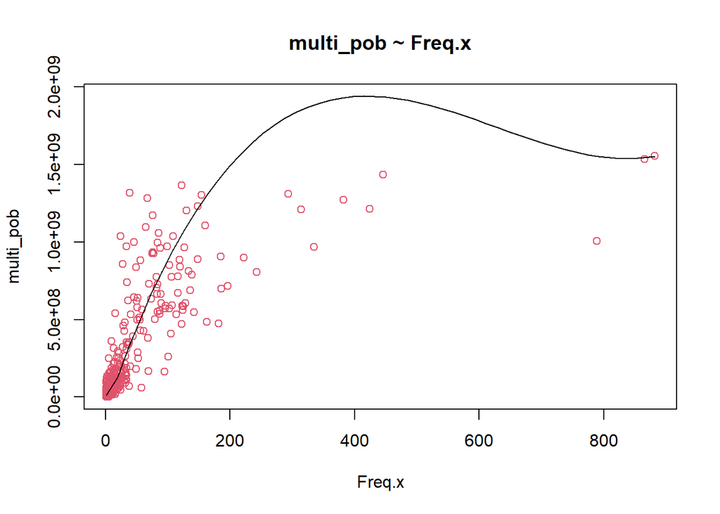

```r
scatter.smooth(x=h_y_m_comuna_corr_01$Freq.x, y=h_y_m_comuna_corr_01$multi_pob, main="multi_pob ~ Freq.x",
     xlab = "Freq.x",
     ylab = "multi_pob",
           col = 2)
```

### 7.2 Outliers

Hemos demostrado en el punto 5.7.2 de [aquí](https://rpubs.com/dataintelligence/expansion_viviendas_001) que la exclusión de ouliers no genera ninguna mejora en el modelo de regresión.

### 7.3 Modelo lineal

Aplicaremos un análisis de regresión lineal del ingreso expandido por zona sobre las frecuencias de respuestas zonales.

```r
linearMod <- lm( multi_pob~(Freq.x) , data=h_y_m_comuna_corr_01)
summary(linearMod)
```

```
##
## Call:
## lm(formula = multi_pob ~ (Freq.x), data = h_y_m_comuna_corr_01)
##
## Residuals:
##        Min         1Q     Median         3Q        Max
## -1.355e+09 -6.366e+07 -5.075e+07 -1.821e+07  1.139e+09
##
## Coefficients:
##             Estimate Std. Error t value Pr(>|t|)
## (Intercept) 66716935    6156145   10.84   <2e-16 ***
## Freq.x       2906369      91396   31.80   <2e-16 ***
## ---
## Signif. codes:  0 '***' 0.001 '**' 0.01 '*' 0.05 '.' 0.1 ' ' 1
##
## Residual standard error: 174400000 on 879 degrees of freedom
## Multiple R-squared:  0.535,  Adjusted R-squared:  0.5344
## F-statistic:  1011 on 1 and 879 DF,  p-value: < 2.2e-16
```

### 7.4 Gráfica de la recta de regresión lineal

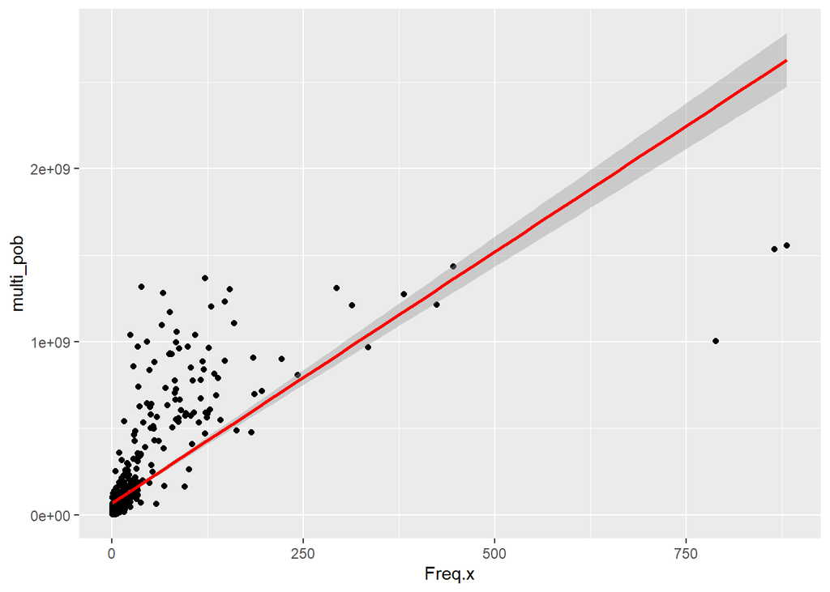

```r
ggplot(h_y_m_comuna_corr_01, aes(x = Freq.x , y = multi_pob)) +
  geom_point() +
  stat_smooth(method = "lm", col = "red")
```

## 8 Modelos alternativos

### 8.1 Modelo cuadrático

$$\hat Y = \beta_0 + \beta_1 X^2$$

```r
linearMod <- lm( multi_pob~(Freq.x^2) , data=h_y_m_comuna_corr_01)
summary(linearMod)
```

```
##
## Call:
## lm(formula = multi_pob ~ (Freq.x^2), data = h_y_m_comuna_corr_01)
##
## Residuals:
##        Min         1Q     Median         3Q        Max
## -1.355e+09 -6.366e+07 -5.075e+07 -1.821e+07  1.139e+09
##
## Coefficients:
##             Estimate Std. Error t value Pr(>|t|)
## (Intercept) 66716935    6156145   10.84   <2e-16 ***
## Freq.x       2906369      91396   31.80   <2e-16 ***
## ---
## Signif. codes:  0 '***' 0.001 '**' 0.01 '*' 0.05 '.' 0.1 ' ' 1
##
## Residual standard error: 174400000 on 879 degrees of freedom
## Multiple R-squared:  0.535,  Adjusted R-squared:  0.5344
## F-statistic:  1011 on 1 and 879 DF,  p-value: < 2.2e-16
```

### 8.2 Modelo cúbico

$$\hat Y = \beta_0 + \beta_1 X^3$$

```r
linearMod <- lm( multi_pob~(Freq.x^3) , data=h_y_m_comuna_corr_01)
summary(linearMod)
```

```
##
## Call:
## lm(formula = multi_pob ~ (Freq.x^3), data = h_y_m_comuna_corr_01)
##
## Residuals:
##        Min         1Q     Median         3Q        Max
## -1.355e+09 -6.366e+07 -5.075e+07 -1.821e+07  1.139e+09
##
## Coefficients:
##             Estimate Std. Error t value Pr(>|t|)
## (Intercept) 66716935    6156145   10.84   <2e-16 ***
## Freq.x       2906369      91396   31.80   <2e-16 ***
## ---
## Signif. codes:  0 '***' 0.001 '**' 0.01 '*' 0.05 '.' 0.1 ' ' 1
##
## Residual standard error: 174400000 on 879 degrees of freedom
## Multiple R-squared:  0.535,  Adjusted R-squared:  0.5344
## F-statistic:  1011 on 1 and 879 DF,  p-value: < 2.2e-16
```

### 8.3 Modelo logarítmico

$$\hat Y = \beta_0 + \beta_1 ln X$$

```r
linearMod <- lm( multi_pob~log(Freq.x) , data=h_y_m_comuna_corr_01)
summary(linearMod)
```

```
##
## Call:
## lm(formula = multi_pob ~ log(Freq.x), data = h_y_m_comuna_corr_01)
##
## Residuals:
##        Min         1Q     Median         3Q        Max
## -398660297 -106101772  -24519545  107024332  913907217
##
## Coefficients:
##               Estimate Std. Error t value Pr(>|t|)
## (Intercept) -102613225    8378144  -12.25   <2e-16 ***
## log(Freq.x)  138517760    3852106   35.96   <2e-16 ***
## ---
## Signif. codes:  0 '***' 0.001 '**' 0.01 '*' 0.05 '.' 0.1 ' ' 1
##
## Residual standard error: 162700000 on 879 degrees of freedom
## Multiple R-squared:  0.5953, Adjusted R-squared:  0.5949
## F-statistic:  1293 on 1 and 879 DF,  p-value: < 2.2e-16
```

### 8.4 Modelo exponencial

$$\hat Y = \beta_0 + \beta_1 e^X$$

No es aplicable sin una transformación pues los valores elevados a $e$ de Freq.x tienden a infinito.

### 8.5 Modelo con raíz cuadrada

$$\hat Y = \beta_0 + \beta_1 \sqrt {X}$$

```r
linearMod <- lm( multi_pob~sqrt(Freq.x) , data=h_y_m_comuna_corr_01)
summary(linearMod)
```

```
##
## Call:
## lm(formula = multi_pob ~ sqrt(Freq.x), data = h_y_m_comuna_corr_01)
##
## Residuals:
##        Min         1Q     Median         3Q        Max
## -837014900  -45589952   -4175876   26767814  977025428
##
## Coefficients:
##               Estimate Std. Error t value Pr(>|t|)
## (Intercept)  -87267028    5761736  -15.15   <2e-16 ***
## sqrt(Freq.x)  68695610    1283600   53.52   <2e-16 ***
## ---
## Signif. codes:  0 '***' 0.001 '**' 0.01 '*' 0.05 '.' 0.1 ' ' 1
##
## Residual standard error: 123900000 on 879 degrees of freedom
## Multiple R-squared:  0.7652, Adjusted R-squared:  0.7649
## F-statistic:  2864 on 1 and 879 DF,  p-value: < 2.2e-16
```

### 8.6 Modelo raíz-raíz

$$\hat Y = {\beta_0}^2 + 2 \beta_0 \beta_1 \sqrt{X}+ \beta_1^2 X$$

```r
linearMod <- lm( sqrt(multi_pob)~sqrt(Freq.x) , data=h_y_m_comuna_corr_01)
summary(linearMod)
```

```
##
## Call:
## lm(formula = sqrt(multi_pob) ~ sqrt(Freq.x), data = h_y_m_comuna_corr_01)
##
## Residuals:
##    Min     1Q Median     3Q    Max
## -28087  -1916   -613   1095  21670
##
## Coefficients:
##              Estimate Std. Error t value Pr(>|t|)
## (Intercept)   1736.48     174.03   9.978   <2e-16 ***
## sqrt(Freq.x)  2066.91      38.77  53.311   <2e-16 ***
## ---
## Signif. codes:  0 '***' 0.001 '**' 0.01 '*' 0.05 '.' 0.1 ' ' 1
##
## Residual standard error: 3742 on 879 degrees of freedom
## Multiple R-squared:  0.7638, Adjusted R-squared:  0.7635
## F-statistic:  2842 on 1 and 879 DF,  p-value: < 2.2e-16
```

### 8.7 Modelo log-raíz

$$\hat Y = e^{\beta_0 + \beta_1 \sqrt{X}}$$

```r
linearMod <- lm( log(multi_pob)~sqrt(Freq.x) , data=h_y_m_comuna_corr_01)
summary(linearMod)
```

```
##
## Call:
## lm(formula = log(multi_pob) ~ sqrt(Freq.x), data = h_y_m_comuna_corr_01)
##
## Residuals:
##     Min      1Q  Median      3Q     Max
## -5.6818 -0.6101  0.1052  0.6797  2.7577
##
## Coefficients:
##              Estimate Std. Error t value Pr(>|t|)
## (Intercept)  16.25640    0.04708   345.3   <2e-16 ***
## sqrt(Freq.x)  0.35659    0.01049    34.0   <2e-16 ***
## ---
## Signif. codes:  0 '***' 0.001 '**' 0.01 '*' 0.05 '.' 0.1 ' ' 1
##
## Residual standard error: 1.012 on 879 degrees of freedom
## Multiple R-squared:  0.5681, Adjusted R-squared:  0.5676
## F-statistic:  1156 on 1 and 879 DF,  p-value: < 2.2e-16
```

### 8.8 Modelo raíz-log

$$\hat Y = {\beta_0}^2 + 2 \beta_0 \beta_1 \ln{X}+ \beta_1^2 ln^2X$$

```r
linearMod <- lm( sqrt(multi_pob)~log(Freq.x) , data=h_y_m_comuna_corr_01)
summary(linearMod)
```

```
##
## Call:
## lm(formula = sqrt(multi_pob) ~ log(Freq.x), data = h_y_m_comuna_corr_01)
##
## Residuals:
##      Min       1Q   Median       3Q      Max
## -11481.3  -2916.9   -338.5   2299.9  18848.0
##
## Coefficients:
##             Estimate Std. Error t value Pr(>|t|)
## (Intercept)   522.10     205.39   2.542   0.0112 *
## log(Freq.x)  4625.19      94.43  48.978   <2e-16 ***
## ---
## Signif. codes:  0 '***' 0.001 '**' 0.01 '*' 0.05 '.' 0.1 ' ' 1
##
## Residual standard error: 3987 on 879 degrees of freedom
## Multiple R-squared:  0.7318, Adjusted R-squared:  0.7315
## F-statistic:  2399 on 1 and 879 DF,  p-value: < 2.2e-16
```

### 8.9 Modelo log-log

$$\hat Y = e^{\beta_0+\beta_1 ln{X}}$$

```r
linearMod <- lm( log(multi_pob)~log(Freq.x) , data=h_y_m_comuna_corr_01)
summary(linearMod)
```

```
##
## Call:
## lm(formula = log(multi_pob) ~ log(Freq.x), data = h_y_m_comuna_corr_01)
##
## Residuals:
##      Min       1Q   Median       3Q      Max
## -2.93398 -0.50305  0.03724  0.51433  2.60261
##
## Coefficients:
##             Estimate Std. Error t value Pr(>|t|)
## (Intercept) 15.84901    0.04193  378.02   <2e-16 ***
## log(Freq.x)  0.91823    0.01928   47.63   <2e-16 ***
## ---
## Signif. codes:  0 '***' 0.001 '**' 0.01 '*' 0.05 '.' 0.1 ' ' 1
##
## Residual standard error: 0.814 on 879 degrees of freedom
## Multiple R-squared:  0.7208, Adjusted R-squared:  0.7204
## F-statistic:  2269 on 1 and 879 DF,  p-value: < 2.2e-16
```

## 9 Modelo raíz cuadrada (**r_sqrt**)

Es éste el modelo que nos entrega el mayor coeficiente de determinación de todos (0.7649).

### 9.1 Diagrama de dispersión sobre **r_sqrt**

Desplegamos una curva suavizada por loess en el diagrama de dispersión.

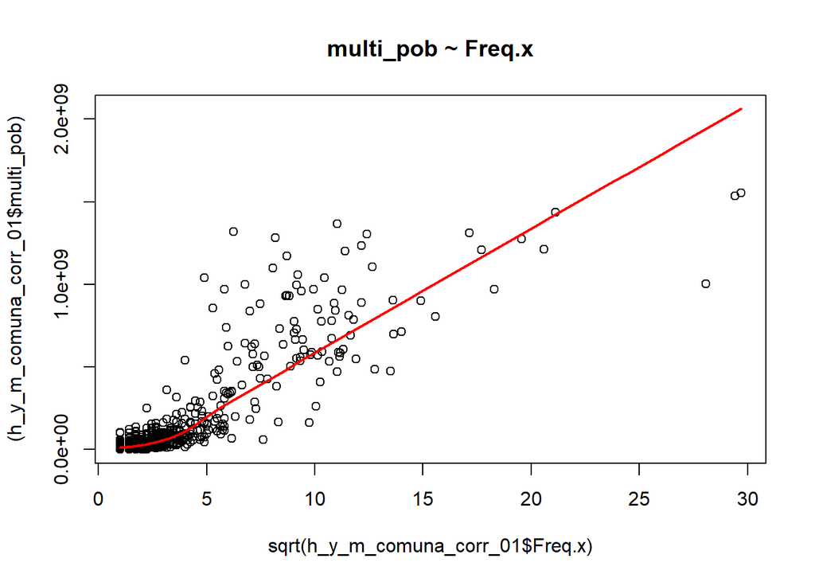

```r
scatter.smooth(x=sqrt(h_y_m_comuna_corr_01$Freq.x), y=(h_y_m_comuna_corr_01$multi_pob), lpars = list(col = "red", lwd = 2, lty = 1), main="multi_pob ~ Freq.x")
```

### 9.2 Modelo **r_sqrt**

Observemos nuevamente el resultado sobre **r_sqrt**.

```r
linearMod <- lm(( multi_pob)~sqrt(Freq.x) , data=h_y_m_comuna_corr_01)
summary(linearMod)
```

```
##
## Call:
## lm(formula = (multi_pob) ~ sqrt(Freq.x), data = h_y_m_comuna_corr_01)
##
## Residuals:
##        Min         1Q     Median         3Q        Max
## -837014900  -45589952   -4175876   26767814  977025428
##
## Coefficients:
##               Estimate Std. Error t value Pr(>|t|)
## (Intercept)  -87267028    5761736  -15.15   <2e-16 ***
## sqrt(Freq.x)  68695610    1283600   53.52   <2e-16 ***
## ---
## Signif. codes:  0 '***' 0.001 '**' 0.01 '*' 0.05 '.' 0.1 ' ' 1
##
## Residual standard error: 123900000 on 879 degrees of freedom
## Multiple R-squared:  0.7652, Adjusted R-squared:  0.7649
## F-statistic:  2864 on 1 and 879 DF,  p-value: < 2.2e-16
```

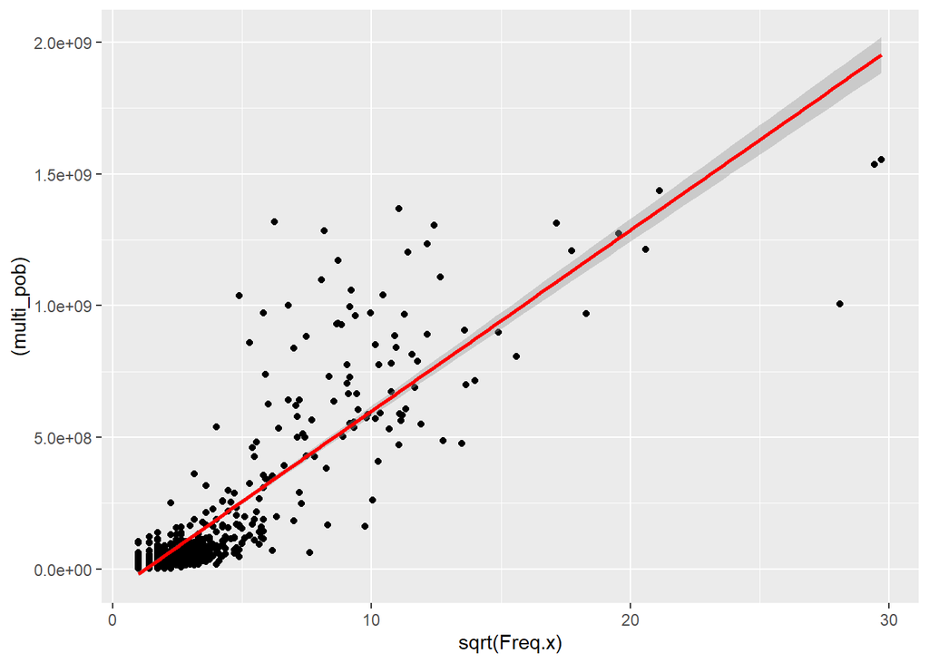

```r
ggplot(h_y_m_comuna_corr_01, aes(x = sqrt(Freq.x) , y = (multi_pob))) +
  geom_point() +
  stat_smooth(method = "lm", col = "red")
```

### 9.3 Análisis de residuos

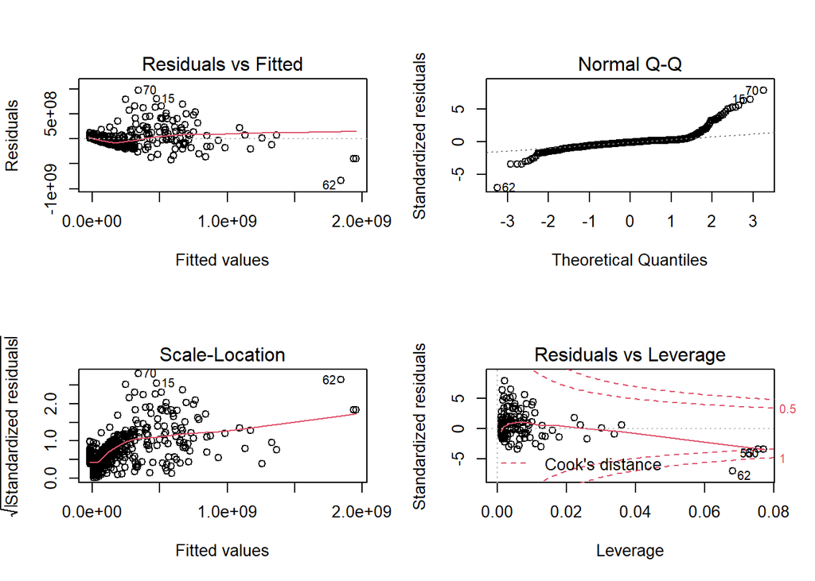

```r
par(mfrow = c (2,2))
plot(linearMod)
```

### 9.4 Ecuación del modelo

$$\hat Y = -87267028 + 68695610 \cdot \sqrt {X}$$

## 10 Aplicación la regresión a los valores de la variable a nivel de zona

Esta nueva variable se llamará: est_ing

```r
h_y_m_comuna_corr_01$est_ing <- -87267028 + 68695610 * sqrt (h_y_m_comuna_corr_01$Freq.x)

r3_100 <- h_y_m_comuna_corr_01[c(1:100),]
kbl(r3_100) %>%
  kable_styling(bootstrap_options = c("striped", "hover")) %>%
  kable_paper() %>%
  scroll_box(width = "100%", height = "300px")
```

| zona | código.x | Freq.x | anio | comuna.x | promedio_i | año | comuna.y | personas | Ingresos_expandidos | Freq.y | p_poblacional | código.y | multi_pob | est_ing |
| --- | --- | --- | --- | --- | --- | --- | --- | --- | --- | --- | --- | --- | --- | --- |
| 16101011001 | 16101 | 52 | 2017 | Chillán | 267443.2 | 2017 | 16101 | 184739 | 49407186552 | 1080 | 0.0058461 | 16101 | 288838640 | 408104061 |
| 16101011002 | 16101 | 105 | 2017 | Chillán | 267443.2 | 2017 | 16101 | 184739 | 49407186552 | 1525 | 0.0082549 | 16101 | 407850857 | 616653506 |
| 16101011003 | 16101 | 142 | 2017 | Chillán | 267443.2 | 2017 | 16101 | 184739 | 49407186552 | 2051 | 0.0111021 | 16101 | 548525972 | 731335641 |
| 16101011004 | 16101 | 163 | 2017 | Chillán | 267443.2 | 2017 | 16101 | 184739 | 49407186552 | 1819 | 0.0098463 | 16101 | 486479154 | 789779809 |
| 16101021001 | 16101 | 10 | 2017 | Chillán | 267443.2 | 2017 | 16101 | 184739 | 49407186552 | 1345 | 0.0072805 | 16101 | 359711084 | 129967565 |
| 16101021002 | 16101 | 114 | 2017 | Chillán | 267443.2 | 2017 | 16101 | 184739 | 49407186552 | 1991 | 0.0107774 | 16101 | 532479381 | 646201376 |
| 16101021003 | 16101 | 87 | 2017 | Chillán | 267443.2 | 2017 | 16101 | 184739 | 49407186552 | 2007 | 0.0108640 | 16101 | 536758472 | 553482966 |
| 16101021004 | 16101 | 79 | 2017 | Chillán | 267443.2 | 2017 | 16101 | 184739 | 49407186552 | 1882 | 0.0101873 | 16101 | 503328074 | 523312909 |
| 16101031001 | 16101 | 335 | 2017 | Chillán | 267443.2 | 2017 | 16101 | 184739 | 49407186552 | 3622 | 0.0196060 | 16101 | 968679216 | 1170069080 |
| 16101031002 | 16101 | 116 | 2017 | Chillán | 267443.2 | 2017 | 16101 | 184739 | 49407186552 | 2516 | 0.0136192 | 16101 | 672887053 | 652607335 |
| 16101031003 | 16101 | 125 | 2017 | Chillán | 267443.2 | 2017 | 16101 | 184739 | 49407186552 | 2184 | 0.0118221 | 16101 | 584095916 | 680773241 |
| 16101031004 | 16101 | 55 | 2017 | Chillán | 267443.2 | 2017 | 16101 | 184739 | 49407186552 | 1866 | 0.0101007 | 16101 | 499048983 | 422193251 |
| 16101041001 | 16101 | 119 | 2017 | Chillán | 267443.2 | 2017 | 16101 | 184739 | 49407186552 | 3315 | 0.0179442 | 16101 | 886574158 | 662113605 |
| 16101041002 | 16101 | 41 | 2017 | Chillán | 267443.2 | 2017 | 16101 | 184739 | 49407186552 | 1999 | 0.0108207 | 16101 | 534618927 | 352599497 |
| 16101041003 | 16101 | 67 | 2017 | Chillán | 267443.2 | 2017 | 16101 | 184739 | 49407186552 | 4799 | 0.0259772 | 16101 | 1283459845 | 475030774 |
| 16101041004 | 16101 | 35 | 2017 | Chillán | 267443.2 | 2017 | 16101 | 184739 | 49407186552 | 2766 | 0.0149725 | 16101 | 739747850 | 319141682 |
| 16101042032 | 16101 | 1 | 2017 | Chillán | 267443.2 | 2017 | 16101 | 184739 | 49407186552 | 30 | 0.0001624 | 16101 | 8023296 | -18571418 |
| 16101051001 | 16101 | 44 | 2017 | Chillán | 267443.2 | 2017 | 16101 | 184739 | 49407186552 | 1466 | 0.0079355 | 16101 | 392071709 | 368408098 |
| 16101051002 | 16101 | 382 | 2017 | Chillán | 267443.2 | 2017 | 16101 | 184739 | 49407186552 | 4764 | 0.0257877 | 16101 | 1274099333 | 1255376324 |
| 16101051003 | 16101 | 73 | 2017 | Chillán | 267443.2 | 2017 | 16101 | 184739 | 49407186552 | 2374 | 0.0128506 | 16101 | 634910121 | 499668521 |
| 16101051004 | 16101 | 16 | 2017 | Chillán | 267443.2 | 2017 | 16101 | 184739 | 49407186552 | 2018 | 0.0109235 | 16101 | 539700347 | 187515412 |
| 16101051005 | 16101 | 424 | 2017 | Chillán | 267443.2 | 2017 | 16101 | 184739 | 49407186552 | 4539 | 0.0245698 | 16101 | 1213924617 | 1327262158 |
| 16101052010 | 16101 | 7 | 2017 | Chillán | 267443.2 | 2017 | 16101 | 184739 | 49407186552 | 112 | 0.0006063 | 16101 | 29953637 | 94484472 |
| 16101052026 | 16101 | 9 | 2017 | Chillán | 267443.2 | 2017 | 16101 | 184739 | 49407186552 | 355 | 0.0019216 | 16101 | 94942331 | 118819802 |
| 16101052027 | 16101 | 9 | 2017 | Chillán | 267443.2 | 2017 | 16101 | 184739 | 49407186552 | 362 | 0.0019595 | 16101 | 96814433 | 118819802 |
| 16101052028 | 16101 | 32 | 2017 | Chillán | 267443.2 | 2017 | 16101 | 184739 | 49407186552 | 345 | 0.0018675 | 16101 | 92267899 | 301334025 |
| 16101061001 | 16101 | 5 | 2017 | Chillán | 267443.2 | 2017 | 16101 | 184739 | 49407186552 | 941 | 0.0050937 | 16101 | 251664037 | 66341026 |
| 16101062003 | 16101 | 29 | 2017 | Chillán | 267443.2 | 2017 | 16101 | 184739 | 49407186552 | 638 | 0.0034535 | 16101 | 170628752 | 282670153 |
| 16101062014 | 16101 | 18 | 2017 | Chillán | 267443.2 | 2017 | 16101 | 184739 | 49407186552 | 348 | 0.0018837 | 16101 | 93070228 | 204183762 |
| 16101062024 | 16101 | 22 | 2017 | Chillán | 267443.2 | 2017 | 16101 | 184739 | 49407186552 | 451 | 0.0024413 | 16101 | 120616876 | 234943944 |

[output cut: 70 more lines]

## 11 División del valor estimado entre la población total de la zona para obtener el ingreso medio por zona

$$Ingreso \_ Medio\_zona = est\_ing / (personas * p\_poblacional)$$

```r
h_y_m_comuna_corr_01$ing_medio_zona <- h_y_m_comuna_corr_01$est_ing  /( h_y_m_comuna_corr_01$personas  * h_y_m_comuna_corr_01$p_poblacional)

r3_100 <- h_y_m_comuna_corr_01[c(1:100),]
kbl(r3_100) %>%
  kable_styling(bootstrap_options = c("striped", "hover")) %>%
  kable_paper() %>%
  scroll_box(width = "100%", height = "300px")
```

| zona | código.x | Freq.x | anio | comuna.x | promedio_i | año | comuna.y | personas | Ingresos_expandidos | Freq.y | p_poblacional | código.y | multi_pob | est_ing | ing_medio_zona |
| --- | --- | --- | --- | --- | --- | --- | --- | --- | --- | --- | --- | --- | --- | --- | --- |
| 16101011001 | 16101 | 52 | 2017 | Chillán | 267443.2 | 2017 | 16101 | 184739 | 49407186552 | 1080 | 0.0058461 | 16101 | 288838640 | 408104061 | 377874.13 |
| 16101011002 | 16101 | 105 | 2017 | Chillán | 267443.2 | 2017 | 16101 | 184739 | 49407186552 | 1525 | 0.0082549 | 16101 | 407850857 | 616653506 | 404362.95 |
| 16101011003 | 16101 | 142 | 2017 | Chillán | 267443.2 | 2017 | 16101 | 184739 | 49407186552 | 2051 | 0.0111021 | 16101 | 548525972 | 731335641 | 356575.15 |
| 16101011004 | 16101 | 163 | 2017 | Chillán | 267443.2 | 2017 | 16101 | 184739 | 49407186552 | 1819 | 0.0098463 | 16101 | 486479154 | 789779809 | 434183.51 |
| 16101021001 | 16101 | 10 | 2017 | Chillán | 267443.2 | 2017 | 16101 | 184739 | 49407186552 | 1345 | 0.0072805 | 16101 | 359711084 | 129967565 | 96630.16 |
| 16101021002 | 16101 | 114 | 2017 | Chillán | 267443.2 | 2017 | 16101 | 184739 | 49407186552 | 1991 | 0.0107774 | 16101 | 532479381 | 646201376 | 324561.21 |
| 16101021003 | 16101 | 87 | 2017 | Chillán | 267443.2 | 2017 | 16101 | 184739 | 49407186552 | 2007 | 0.0108640 | 16101 | 536758472 | 553482966 | 275776.27 |
| 16101021004 | 16101 | 79 | 2017 | Chillán | 267443.2 | 2017 | 16101 | 184739 | 49407186552 | 1882 | 0.0101873 | 16101 | 503328074 | 523312909 | 278062.12 |
| 16101031001 | 16101 | 335 | 2017 | Chillán | 267443.2 | 2017 | 16101 | 184739 | 49407186552 | 3622 | 0.0196060 | 16101 | 968679216 | 1170069080 | 323045.02 |
| 16101031002 | 16101 | 116 | 2017 | Chillán | 267443.2 | 2017 | 16101 | 184739 | 49407186552 | 2516 | 0.0136192 | 16101 | 672887053 | 652607335 | 259382.88 |
| 16101031003 | 16101 | 125 | 2017 | Chillán | 267443.2 | 2017 | 16101 | 184739 | 49407186552 | 2184 | 0.0118221 | 16101 | 584095916 | 680773241 | 311709.36 |
| 16101031004 | 16101 | 55 | 2017 | Chillán | 267443.2 | 2017 | 16101 | 184739 | 49407186552 | 1866 | 0.0101007 | 16101 | 499048983 | 422193251 | 226255.76 |
| 16101041001 | 16101 | 119 | 2017 | Chillán | 267443.2 | 2017 | 16101 | 184739 | 49407186552 | 3315 | 0.0179442 | 16101 | 886574158 | 662113605 | 199732.61 |
| 16101041002 | 16101 | 41 | 2017 | Chillán | 267443.2 | 2017 | 16101 | 184739 | 49407186552 | 1999 | 0.0108207 | 16101 | 534618927 | 352599497 | 176387.94 |
| 16101041003 | 16101 | 67 | 2017 | Chillán | 267443.2 | 2017 | 16101 | 184739 | 49407186552 | 4799 | 0.0259772 | 16101 | 1283459845 | 475030774 | 98985.37 |
| 16101041004 | 16101 | 35 | 2017 | Chillán | 267443.2 | 2017 | 16101 | 184739 | 49407186552 | 2766 | 0.0149725 | 16101 | 739747850 | 319141682 | 115380.22 |
| 16101042032 | 16101 | 1 | 2017 | Chillán | 267443.2 | 2017 | 16101 | 184739 | 49407186552 | 30 | 0.0001624 | 16101 | 8023296 | -18571418 | -619047.27 |
| 16101051001 | 16101 | 44 | 2017 | Chillán | 267443.2 | 2017 | 16101 | 184739 | 49407186552 | 1466 | 0.0079355 | 16101 | 392071709 | 368408098 | 251301.57 |
| 16101051002 | 16101 | 382 | 2017 | Chillán | 267443.2 | 2017 | 16101 | 184739 | 49407186552 | 4764 | 0.0257877 | 16101 | 1274099333 | 1255376324 | 263513.08 |
| 16101051003 | 16101 | 73 | 2017 | Chillán | 267443.2 | 2017 | 16101 | 184739 | 49407186552 | 2374 | 0.0128506 | 16101 | 634910121 | 499668521 | 210475.37 |
| 16101051004 | 16101 | 16 | 2017 | Chillán | 267443.2 | 2017 | 16101 | 184739 | 49407186552 | 2018 | 0.0109235 | 16101 | 539700347 | 187515412 | 92921.41 |
| 16101051005 | 16101 | 424 | 2017 | Chillán | 267443.2 | 2017 | 16101 | 184739 | 49407186552 | 4539 | 0.0245698 | 16101 | 1213924617 | 1327262158 | 292412.90 |
| 16101052010 | 16101 | 7 | 2017 | Chillán | 267443.2 | 2017 | 16101 | 184739 | 49407186552 | 112 | 0.0006063 | 16101 | 29953637 | 94484472 | 843611.36 |
| 16101052026 | 16101 | 9 | 2017 | Chillán | 267443.2 | 2017 | 16101 | 184739 | 49407186552 | 355 | 0.0019216 | 16101 | 94942331 | 118819802 | 334703.67 |
| 16101052027 | 16101 | 9 | 2017 | Chillán | 267443.2 | 2017 | 16101 | 184739 | 49407186552 | 362 | 0.0019595 | 16101 | 96814433 | 118819802 | 328231.50 |
| 16101052028 | 16101 | 32 | 2017 | Chillán | 267443.2 | 2017 | 16101 | 184739 | 49407186552 | 345 | 0.0018675 | 16101 | 92267899 | 301334025 | 873431.96 |
| 16101061001 | 16101 | 5 | 2017 | Chillán | 267443.2 | 2017 | 16101 | 184739 | 49407186552 | 941 | 0.0050937 | 16101 | 251664037 | 66341026 | 70500.56 |
| 16101062003 | 16101 | 29 | 2017 | Chillán | 267443.2 | 2017 | 16101 | 184739 | 49407186552 | 638 | 0.0034535 | 16101 | 170628752 | 282670153 | 443056.67 |
| 16101062014 | 16101 | 18 | 2017 | Chillán | 267443.2 | 2017 | 16101 | 184739 | 49407186552 | 348 | 0.0018837 | 16101 | 93070228 | 204183762 | 586734.95 |
| 16101062024 | 16101 | 22 | 2017 | Chillán | 267443.2 | 2017 | 16101 | 184739 | 49407186552 | 451 | 0.0024413 | 16101 | 120616876 | 234943944 | 520940.01 |

[output cut: 70 more lines]

Guardamos:

```r
saveRDS(h_y_m_comuna_corr_01, "casen_censo_region_16.rds")
```

## 12 Referencias

https://rpubs.com/osoramirez/316691

https://dataintelligencechile.shinyapps.io/casenfinal

Manual_de_usuario_Censo_2017_16R.pdf

http://www.censo2017.cl/microdatos/

Censo de Población y Vivienda

https://www.ine.cl/estadisticas/sociales/censos-de-poblacion-y-vivienda/poblacion-y-vivienda

http://r-statistics.co/Linear-Regression.html